# CCDB Tutorial

## 2.Cleaning a sporophytic chromosome number

Simmilarly to the gametophytic clean, you can do sporophytic cleanings through the function `sporophytic.translator()`. This function will create a table with 5 columns 1.Genus= Genus name, 2.Species= Species name (format usable to match with phylogenies) 3.CountTranslation (numeric)= A numeric vector with the counts ready to use for analyses 4.Type= sporophytic 5. CountOriginal= The original record in CCDB. This is done to control for errors.

**Example 1**

```r
# This has one record and B chromosomes
angiospermdata[1831,]
```

```
##        resolved_binomial gametophytic sporophytic          resolved_name
## 1831 Sambucus_canadensis         <NA>   38+(0-2B) Sambucus canadensis L.
##      Examples    Genus    Species Var Subespeciesname
## 1831       NA Sambucus canadensis
```

```r
# Corrected record
sporophytic.translator(angiospermdata[1831,])
```

```
##      Genus             Species CountTranslation        Type CountOriginal
## 1 Sambucus Sambucus_canadensis               38 sporophytic     38+(0-2B)
```

## 3. Creating clean records for a genus or all angiosperms.

If you want to clean a whole genus or subset you want to use the function `CCDBcurator()` . The input for this function needs either one row or multiple rows from your dataset. **Example1**

```r
# Clean all the chromosome counts for genus Acanthus
index<-which(angiospermdata$Genus=="Acanthus") #which data in angiospermdata are Acanthus?

acanthus.sample<-angiospermdata[index,] # this are all the Acanthus in angiospermdata

Acanthus.clean<-CCDBcurator(acanthus.sample) # Prints a warning when there are no sporophytic or gametophytic entries in a record
```

[output not shown]

So the clean records and Haploid number of chromosomes and the possibility of aneuploidy (sporophyte record non-divisible by 2) are stored in the object

```r
Acanthus.clean
```

```
##       Genus              Species CountTranslation         Type
## 1  Acanthus      Acanthus_mollis               24 gametophytic
## 2  Acanthus      Acanthus_mollis               56  sporophytic
## 3  Acanthus      Acanthus_mollis               80  sporophytic
## 4  Acanthus    Acanthus_spinosus              112  sporophytic
## 5  Acanthus      Acanthus_mollis               56  sporophytic
## 6  Acanthus Acanthus_ilicifolius               44  sporophytic
## 7  Acanthus Acanthus_ilicifolius               44  sporophytic
## 8  Acanthus Acanthus_ilicifolius               44  sporophytic
## 9  Acanthus   Acanthus_pubescens               56  sporophytic
## 10 Acanthus      Acanthus_mollis               80  sporophytic
## 11 Acanthus      Acanthus_mollis               28 gametophytic
## 12 Acanthus    Acanthus_spinosus               56  sporophytic
## 13 Acanthus    Acanthus_spinosus               56 gametophytic
## 14 Acanthus Acanthus_ebracteatus               44  sporophytic
```

[output cut: 51 more lines]

With this output you can do multiple things for example check by genus how many haploid numbers you have and how many times they appear

```r
genus.table<- table(Acanthus.clean$Genus,Acanthus.clean$HaploidNumber)
genus.table
```

```
##
##            22 24 28 40 56
##   Acanthus  9  6  9  4  4
```

Or check how many records by species

```r
species.table<-table(Acanthus.clean$Species, Acanthus.clean$HaploidNumber)
species.table
```

```
##
##                        22 24 28 40 56
##   Acanthus_ebracteatus  2  0  0  0  0
##   Acanthus_ilicifolius  6  5  0  0  0
##   Acanthus_mollis       0  1  6  2  0
##   Acanthus_pubescens    0  0  1  0  0
##   Acanthus_spinosus     0  0  2  2  4
##   Acanthus_volubilis    1  0  0  0  0
```

You can plot to detect the most likely x-number and if the gametophytic and sporophytic counts match

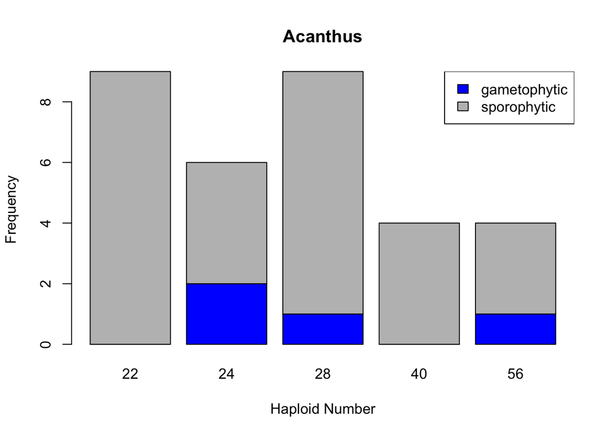

```r
small<-as.data.frame(table(Acanthus.clean$HaploidNumber,Acanthus.clean$Type)) # Acanthus.clean is used here
names(small)<-c("HaploidNumber","Type","Freq") # The rest remains the same for any other example

small_ordered = small[with(small, order(HaploidNumber,Type)),]
data_ordered=matrix(small_ordered$Freq, ncol=2,byrow=TRUE)
colnames(data_ordered)=levels(small_ordered$Type)
rownames(data_ordered)=levels(small_ordered$HaploidNumber)
colorsplot<-c("lightblue")
barplot(t(data_ordered), col=c("blue","gray"), main="Acanthus",xlab="Haploid Number",ylab="Frequency")
legend("topright",fill=c("blue","gray"),legend=colnames(data_ordered))
```